# EDPS 845 Assignment 1

Tony Albano

## Overview

Demonstrate your mastery of concepts and procedures covered in *An Introduction to R*, chapters 1 through 9. See Appendix A for examples.

Complete this assignment by responding to each question below using your own original code, in addition to answering any questions. Follow Google’s [R coding conventions](https://google.github.io/styleguide/Rguide.xml), and use [R markdown](http://rmarkdown.rstudio.com/index.html) formatting for your responses, with example R code written as

```r
# Comment within some example code
```

Your file should have an Rmd extension, and you should check that it compiles to HTML using the *Knit* command in RStudio (this runs `knitr::knit()` on the file). Note that you can already *Knit* this file to see how it works.

## Exercises

### Chapter 1

1. Show that you can access the home page for the HTML R help menu, as well as help files for individual functions.

```r
# This opens R help
help.start()
```

```
## starting httpd help server ...
```

```
##  done
```

```
## If the browser launched by '/usr/bin/open' is already running, it
##     is *not* restarted, and you must switch to its window.
## Otherwise, be patient ...
```

2. Demonstrate correct and incorrect naming of R objects.

```r
#Correct naming of object - Example

object<-c(1,2,3)

#Incorrect naming

21object<- c(1,2,3)
```

3. How do you list all available objects in the R workspace? And how do you remove individual objects?

```r
#listing
ls()
#removing
rm()
```

### Chapter 2

1. Create and index a vector using a logical, integer, negative integer, and character vector.

```r
#create a logical vector
#l<- x < 40
#create an integer vector
x<- c(1, 2, 3, 4)
#create a negative integer vector
y <- x[-(1:3)]
#create a character vector
family<- c("Pam", "Ken", "Tom", "Ray")
```

3. Create a simple data frame containing a numeric variable, character variable, and factor with at least 3 levels. Use the data frame to demonstrate how R codes and handles missing data.

```r
#Simple data frame not removing any NA values
myfamily<- data.frame(familynumber= x, names= family, familycolumn=y)
myfamily[myfamily == 1] <- NA
print(myfamily)
```

```
##   familynumber names familycolumn
## 1           NA   Pam            4
## 2            2   Ken            4
## 3            3   Tom            4
## 4            4   Ray            4
```

### Chapter 3

1. Demonstrate how to check and change the modes and attributes of R objects.

```r
state <- c("tas", "sa", "qld", "nsw", "nsw", "nt", "wa", "wa",
"qld", "vic", "nsw", "vic", "qld", "qld", "sa", "tas",
"sa", "nt", "wa", "vic", "qld", "nsw", "nsw", "wa",
"sa", "act", "nsw", "vic", "vic", "act")
statef<-factor(state)
incomes <- c(60, 49, 40, 61, 64, 60, 59, 54, 62, 69, 70, 42, 56,
61, 61, 61, 58, 51, 48, 65, 49, 49, 41, 48, 52, 46,
59, 46, 58, 43)
#Check mode of an object
mode(x)
```

```
## [1] "numeric"
```

```r
#change the mode of an object
xchar<- as.character(x)
mode(xchar)
```

```
## [1] "character"
```

```r
#check length of an object
length(y)
```

```
## [1] 1
```

```r
#attributes
attributes(statef)
```

```
## $levels
## [1] "act" "nsw" "nt"  "qld" "sa"  "tas" "vic" "wa"
##
## $class
## [1] "factor"
```

```r
#change attributes
attrchanged<- attributes(statef)<-NULL
attributes(attrchanged)
```

[output not shown]

### Chapter 4

1. Complete the exercise on page 17, where you calculate 95% confidence intervals for state mean incomes.

```r
#Page 17


incmeans <- tapply(incomes, statef, mean)
stderr <- function(x) sqrt(var(x)/length(x))
incster<-tapply(incomes, statef, stderr)
length(incomes)
```

```
## [1] 30
```

```r
n <- table(statef)
cis<-data.frame(mean=incmeans, stderr=incster, state=names(incmeans),
  lower=qt(.025, n-1),
  upper=qt(.025, n-1, lower.tail=FALSE))
```

2. In what order are the levels of ordered factors stored in?

```r
#alphabetical order
```

### Chapter 5

1. Create an array with dimensions `c(3, 6, 2)` and use it to demonstrate array indexing.

```r
#Create an array with dimensions 3 by 6 by 2
b <- array(1:36, dim=c(3, 6, 2))
```

2. Create a two dimensional array of 100 integers sampled with replacement from the vector 1:20, and use an index array to set the diagonal values to 0.

```r
#Create random sample
d<- c(1:20)
randsample<-sample(d, 100, replace=TRUE)
#Create array to set diagonal values to 0
randomarray<- array(data=randsample, dim=c(10, 10))
i<- array(c(1:10, 10:1),dim=c(10,2))
randomarray[i]
```

```
##  [1] 19  3 17  9 11 17 16 13  6  8
```

```r
randomarray[i]<-0
print(randomarray)
```

```
##       [,1] [,2] [,3] [,4] [,5] [,6] [,7] [,8] [,9] [,10]
##  [1,]    3    2   10   15    1   18   15   10    5     0
##  [2,]   10   16   10   17   12   10   17    3    0    13
##  [3,]   17    9    7   18    6    3   15    0   18     6
##  [4,]    4    8   19   11   20    8    0   20    8    15
##  [5,]    2    3    7   12   19    0   18   11   12     1
##  [6,]   12   13   15   15    0    1   12   16    8     1
##  [7,]    5    9   15    0   15   16   17    8    3    20
##  [8,]   19   17    0    2   18   16    5   14    2    20
##  [9,]   12    0    6   16   16   13   12    1   17    18
## [10,]    0    6    1   18    7   15   12   12    2    13
```

3. Construct the same array using the `array()` function and using a vector with the `dim()` set. Prove they are the same.

```r
#Create array using array()
secondarray<- array(data=randsample, dim=c(4, 25))
#create same array using dim()
seconddim<- randsample ; dim(seconddim) <- c(4, 25)
#prove they are the same
print(secondarray)
```

```
##      [,1] [,2] [,3] [,4] [,5] [,6] [,7] [,8] [,9] [,10] [,11] [,12] [,13]
## [1,]    3    2   12    9    9   10    7    6   18    16     1    19    16
## [2,]   10   12    8    8   17   10   15    1   11     2    12    17     7
## [3,]   17    5    2    3    6    7   15   15   12    16     6    15    18
## [4,]    4   19   16   13    6   19   13   17   15    18    20    18    10
##      [,14] [,15] [,16] [,17] [,18] [,19] [,20] [,21] [,22] [,23] [,24]
## [1,]     3    16    15    18    12    17     8     5    12    17     6
## [2,]     8    16    17    12    12    20    14     3     8     2    15
## [3,]    11    13    15    17    10    11     1    18     3    19     1
## [4,]     1    15     9     5     3    16    12     8     2    13     1
##      [,25]
## [1,]    20
## [2,]    20
## [3,]    18
## [4,]    13
```

```r
print(seconddim)
```

```
##      [,1] [,2] [,3] [,4] [,5] [,6] [,7] [,8] [,9] [,10] [,11] [,12] [,13]
## [1,]    3    2   12    9    9   10    7    6   18    16     1    19    16
## [2,]   10   12    8    8   17   10   15    1   11     2    12    17     7
## [3,]   17    5    2    3    6    7   15   15   12    16     6    15    18
## [4,]    4   19   16   13    6   19   13   17   15    18    20    18    10
##      [,14] [,15] [,16] [,17] [,18] [,19] [,20] [,21] [,22] [,23] [,24]
## [1,]     3    16    15    18    12    17     8     5    12    17     6
## [2,]     8    16    17    12    12    20    14     3     8     2    15
## [3,]    11    13    15    17    10    11     1    18     3    19     1
## [4,]     1    15     9     5     3    16    12     8     2    13     1
##      [,25]
## [1,]    20
## [2,]    20
## [3,]    18
## [4,]    13
```

4. Use your array from 5.1, and another with the same dimensions, to demonstrate how arithmetic works with arrays.

```r
#create second array of same size as array b
c<- array(37:72, dim=c(3, 6, 2))
#demonstrate arithmetic by multiplying outer product
bc<- outer(b, c, "*")
```

5. Show how to clear the dimensions of an array.

```r
vec <- c(bc)
```

### Chapter 6

1. Demonstrate the different ways of subsetting a list.

```r
#Subsetting a list
#One way to subset a list:

mtcars[[1]]
```

```
##  [1] 21.0 21.0 22.8 21.4 18.7 18.1 14.3 24.4 22.8 19.2 17.8 16.4 17.3 15.2
## [15] 10.4 10.4 14.7 32.4 30.4 33.9 21.5 15.5 15.2 13.3 19.2 27.3 26.0 30.4
## [29] 15.8 19.7 15.0 21.4
```

```r
#Or
mtcars$cyl
```

```
##  [1] 6 6 4 6 8 6 8 4 4 6 6 8 8 8 8 8 8 4 4 4 4 8 8 8 8 4 4 4 8 6 8 4
```

2. What is the difference between giving multiple lists to `list()` versus `c()`?

```r
#Using the 'list()' command allows the use of existing objects to form lists.  Using the 'c()' command combines components of existing lists together to form new lists.
newlist <- list(mtcars, randsample)
newlist2 <- c(mtcars, randsample)
```

3. How do data frames in R relate to lists?

```r
# this is a list with the class "data.frame".  They can include restrictions such as having components made up of vectors that all have the same length and row size.
```

4. What is the purpose of `attach()`?

```r
#The 'attach()' function attaches a database to a search path.  This allows the use to refer to the variables by their names rather than as components of a dataframe. For example, if the dataframe 'mtcars' is not attached, you would have to call the cylinder column in the database with 'mtcars$cyl'.  However, if you attached the mtcars data, you could just use 'cyl' to refer to this column.
```

### Chapter 7

1. Demonstrate the different approaches to reading in data from an external file.

```r
#This can be done using the following:
readx<- read.table("/Users/pamela/Desktop/EDPS 845/edps-845/a1/selfeff.txt", header=TRUE, row.names = 1)
scanx <- scan("/Users/pamela/Desktop/EDPS 845/edps-845/a1/selfeff.txt", what="character",skip=1,quiet=TRUE)
datax<- data(cars)
```

### Chapter 8

1. Demonstrate the use of distribution functions to simulate data and calculate probabilities and quantiles.

```r
#Simulate random data with Poisson dist, lambda = 4
Pdata<-rpois(15, 4)
#Calculate probabilities for t distribution
2*pt(-2.43, df = 13)
```

```
## [1] 0.0303309
```

```r
#Calculate Quantiles for F(2, 7)
qf(0.01, 2, 7, lower.tail = FALSE)
```

```
## [1] 9.546578
```

2. Simulate data from a t distribution and check their normality.

```r
#Simulate data from t distribution
tdata<- rt(30, df = n-1)
#Examine normality
stem(tdata)
```

```
##
##   The decimal point is at the |
##
##    -8 | 5
##    -6 |
##    -4 | 9
##    -2 | 1
##    -0 | 31077554430
##     0 | 123444669028
##     2 | 02
##     4 | 5
##     6 | 1
```

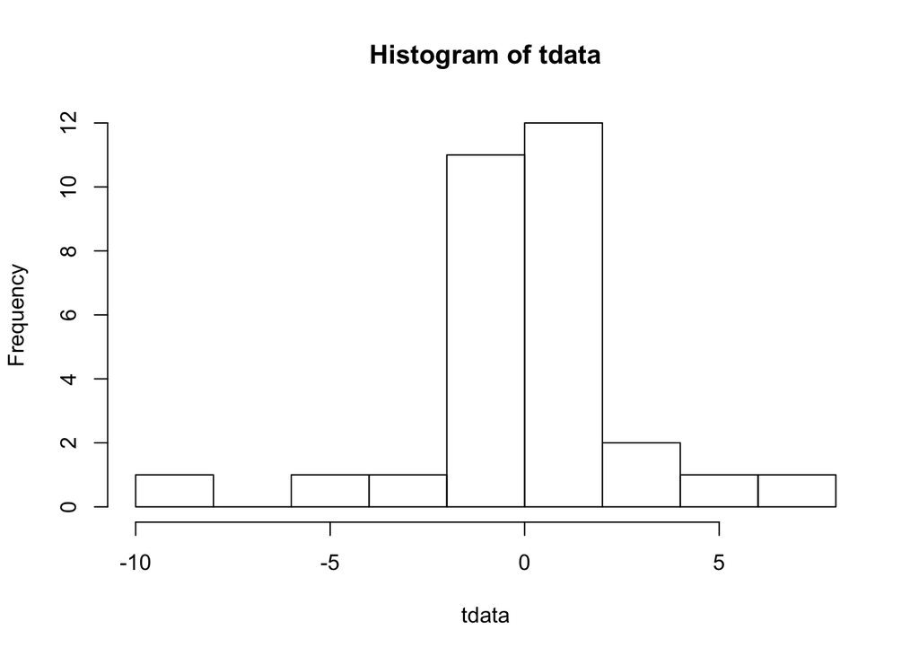

```r
hist(tdata)
```

```r
shapiro.test(tdata)
```

```
##
##  Shapiro-Wilk normality test
##
## data:  tdata
## W = 0.87631, p-value = 0.002322
```

```r
ks.test(tdata, "pnorm", mean = mean(tdata), sd = sqrt(var(tdata)))
```

```
##
##  One-sample Kolmogorov-Smirnov test
##
## data:  tdata
## D = 0.2013, p-value = 0.1529
## alternative hypothesis: two-sided
```

### Chapter 9

1. What is the difference between `if() else` and `ifelse()`?

```r
#ifelse() is a vectorized version of the if/else statement and returns a vector the length of the longest argument, whereas the if() else statement evaluates a single logical argment and returns the appropriate value given the statement.

#example ifelse()
ifelse(randomarray,x,y)
```

```
##       [,1] [,2] [,3] [,4] [,5] [,6] [,7] [,8] [,9] [,10]
##  [1,]    1    3    1    3    1    3    1    3    1     4
##  [2,]    2    4    2    4    2    4    2    4    4     4
##  [3,]    3    1    3    1    3    1    3    4    3     1
##  [4,]    4    2    4    2    4    2    4    2    4     2
##  [5,]    1    3    1    3    1    4    1    3    1     3
##  [6,]    2    4    2    4    4    4    2    4    2     4
##  [7,]    3    1    3    4    3    1    3    1    3     1
##  [8,]    4    2    4    2    4    2    4    2    4     2
##  [9,]    1    4    1    3    1    3    1    3    1     3
## [10,]    4    4    2    4    2    4    2    4    2     4
```

```r
#example if()else
f<-0
if (f< 0) {
   print("Negative number")
} else if (f > 0) {
   print("Positive number")
} else
   print("Zero")
```

```
## [1] "Zero"
```

2. Demonstrate the use of a `for()` loop.

```r
for(i in 1:10) {
  print(rnorm(10))
}
```

```
##  [1]  0.7025391  1.2467267 -0.4402206 -0.3212692 -0.8437867  0.6882582
##  [7]  0.3088954 -0.1771131 -0.1749716 -0.6267468
##  [1] -0.5671537  0.6333337  2.0718890 -0.7202034  2.1549316 -0.9126062
##  [7] -1.1974272 -0.2106003  0.5388791  0.1057089
##  [1] -0.3013731  0.3019202  0.3803604 -1.0737360  1.0253124 -0.7546915
##  [7] -1.1243068 -0.3592828  0.4915724 -0.6485364
##  [1]  2.25908938 -0.37036995  0.03860375 -0.13359092  0.93220569
##  [6] -1.11319787  1.29294073  0.76076542 -0.60920619 -0.93032625
##  [1]  0.78218703  0.16504089  2.86509285  0.87516719  0.71418931
##  [6]  0.49821221 -0.23643467 -0.43150528  0.06714717 -0.83561894
##  [1] -7.328128e-01  4.041595e-02  6.063528e-01 -9.904495e-01  3.028955e+00
##  [6]  7.256009e-01 -6.815678e-01 -1.049450e+00  1.222042e+00 -3.492884e-05
##  [1] -0.51946180 -0.01630436  0.73013952 -0.14951102  0.22339590
##  [6] -1.35652902 -0.74296623  0.51296985 -0.97257044 -1.02034600
##  [1]  1.4079183  0.7735101  1.4628730  0.8701271 -1.7000948  0.8331977
##  [7] -1.2446006  1.6200464  1.8333160 -1.1617598
##  [1] -0.81123403 -0.33751083  0.01142712 -1.37515527 -0.36413000
##  [6] -0.57576185  2.19503546 -0.13419668 -2.23748351 -1.34324769
##  [1] -1.27011459 -0.54934220 -0.39748360  0.62547613 -0.83671282
##  [6] -0.01172509 -0.79562674  0.08410878  0.83994839  0.17089315
```

```r
#sapply will perform the same function for each item in vector

sapply(levels(statef), print)
```

```
## list()
```

```r
sapply(levels(statef), nchar)
```

```
## list()
```